# Testing the Strength of the Statistic Expected Goals in Football

Author

bfw

Install relevant packages:

```r
# Install required packages (run once locally)
install.packages(c(
  "tidyverse",
  "here",
  "kableExtra",
  "patchwork"
))
```

Load relevant packages and upload data:

```r
#load relevant packages
library(here)
library(tidyverse)
library(kableExtra)
library(patchwork)
#upload raw data
df<-read.csv(here("raw data", "my_premier_league_data.csv"))
```

## Project Motivations

There has been controversy surrounding the statistic “expected goals (xG)” since it was introduced in premier league football match analysis in 2016/17. For instance, pundits and general audiences were uncertain about how the statistic is calculated, and what variables are taking into account. Furthermore, it challenges peoples feelings about the outcome of a match, perhaps viewed as objectifying a subjective experience by adding numbers to things that do not illustrate the full story.

## Data Origins

The data used for this project was collected from [footystats.org](https://footystats.org/england/premier-league/xg#) between 01/12/25 and 05/12/25. Part of the [raw data](https://github.com/billy-fw/PSY6422/blob/main/raw%20data/england-premier-league-teams-2018-to-2019-stats.csv) can be downloaded directly from a sample of [.csv files](https://footystats.org/download-stats-csv) offered on the website. However, the csv files containing the rest of the data nesccasary for this project is behind a pay wall. Therefore the data used here was scraped from the website. I created the file “my_premier_league_data.csv” on excel that contains the scraped data.

### Codebook

The data includes variables:

- Season - the football year/season concerned, ranging from 2016/17 (the introduction of xG) to 2024/25,
- Team_name - the name of each of the 20 clubs that was in the premier league that respective season,
- Expected_goals - the average expected goals (xG) of each team per match across the season,
- Actual_goals - the average actual goals scored of each team per match across the season.

Here is an example of the data:

```
   Season            Team_name Expected_goals Actual_goals
1 2016/17 Tottenham Hotspur FC           2.10         2.26
2 2016/17         Liverpool FC           2.00         2.05
3 2016/17   Manchester City FC           1.98         2.11
4 2016/17 Manchester United FC           1.85         1.42
5 2016/17           Arsenal FC           1.81         2.03
6 2016/17           Chelsea FC           1.79         2.24
```

## Research Questions

This project aims to evaluate the usefulness and reliability of the expected goals (xG) statistic in football analysis. Specifically, it seeks to answer the following questions:

## Data Preparation

The raw data set was created manually to be analysis-ready, therefore no major data wrangling (e.g. handling missing values or recoding variables) was required.

However, several preparation and validation steps were undertaken:

The raw data were then used directly to generate summary tables and visualisations.

```r
cor_by_season <- df %>%
  group_by(Season) %>%
  summarise(r = round(cor(Expected_goals, Actual_goals, method = "pearson"), 3))
head(cor_by_season)
```

```
# A tibble: 6 × 2
  Season      r
  <chr>   <dbl>
1 2016/17 0.876
2 2017/18 0.93
3 2018/19 0.891
4 2019/20 0.923
5 2020/21 0.742
6 2021/22 0.923
```

## Visualizations

The following visualisations were created to explore the relationship between expected goals and actual goals, both overall and across individual seasons.

### Overarching Trend

First, I wanted to check whether there was an overall correlation between variables expected goals and actual goals.

```r
#test correlation
ovr_cor<-cor(df$Expected_goals, df$Actual_goals)
#round to 3 d.p
ovr_cor_rounded<-round(ovr_cor, 3)
#print result
paste("r=", ovr_cor_rounded)
```

```
[1] "r= 0.825"
```

Pearson’s correlation coefficient (r) indicates a strong relationship between xG and actual goals.

We can visualize this relationship via a scatter plot:

#### Scatter Plot

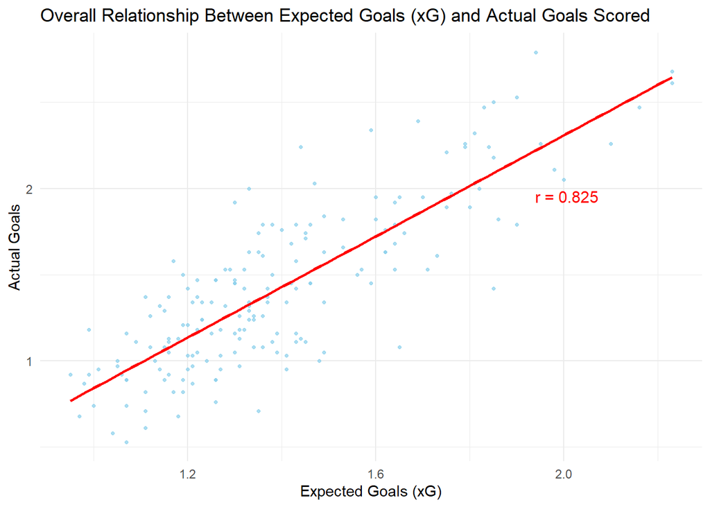

```r
# Create scatter plot of xG and actual goals across all seasons
scatter_plot<-ggplot(data = df,
               aes(x = Expected_goals,
                   y = Actual_goals)) +
  geom_point(size = 0.9, ## Add scatter function
             color = "skyblue",
             alpha = 0.7) +
  geom_smooth(method = "lm", ## Add regression line
              se = FALSE,
              color = "red") +
  labs(title = "Overall Relationship Between Expected Goals (xG) and Actual Goals Scored ", ## Add labels
       x = "Expected Goals (xG)",
       y = "Actual Goals"
  ) +
  annotate( ## Add correlation coefficient
    "text",
    x = max(df$Expected_goals) * 0.9, ## Place text 90% of the length along the x-axis
    y = max(df$Actual_goals) * 0.7,  ## 70% across the y axis
    label = paste("r =", ovr_cor_rounded),
    size = 4,
    color = "red"
  ) +
  theme_minimal() ## Set simple theme
scatter_plot ##View plot
```

### Per Season Trends

Next I wanted to check whether the strength of this relationship has changed since the introduction of xG.

Here is a correlation matrix of xG and actual goals, per season:

```r
# Check correlations per season and compare to mean
## Added again for clarity of code
cor_by_season <- df %>%
  group_by(Season) %>% ## Group data by season
  summarise(
    r = round(
      cor(Expected_goals, Actual_goals,
          method = "pearson"),
      3
      )
    )
cor_by_season_col <- df %>% ## Add color to specific values/conditional formatting
  group_by(Season) %>% ## Group by season
  summarise(
    r = round(
      cor(Expected_goals, Actual_goals,
          method = "pearson"),
      3
      )
    ) %>%
  mutate( ## Red < mean, green> mean
    r = cell_spec(
    r,
    color = ifelse(r < ovr_cor, "red", "green")
   )
  )
## Display results
cor_by_season_col %>%
  kable(
    escape = FALSE, ## Allows html formatting
    align = "c", ## Centre align
    caption = "Correlation by Season"
    )
```

Correlation by Season

| Season | r |
| --- | --- |
| 2016/17 | 0.876 |
| 2017/18 | 0.93 |
| 2018/19 | 0.891 |
| 2019/20 | 0.923 |
| 2020/21 | 0.742 |
| 2021/22 | 0.923 |
| 2022/23 | 0.859 |
| 2023/24 | 0.844 |
| 2024/25 | 0.879 |

This table shows that only season 2020/21 falls below the mean (0.742<0.825) as is highlighted in red. Whereas each other season remained above the mean and is somewhat consistent in value. This is reinforced through the accompanying line chart and box plot, highlighting the consistency in values; other than season 2020/21, which acts as an outlier:

#### Line Chart (left) and Box Plot (right)

```r
# Identify potential outlier and visualize correlation trends across seasons
cor_by_season_out <- cor_by_season %>%
  mutate(
    is_outlier_season = ifelse(Season == "2020/21", TRUE, FALSE) ## Flag 2020/21 season as potential outlier
    )
## Line plot showing correlation trend across seasons
line_plot <- ggplot(cor_by_season_out, aes(x = Season, y = r, group = 1)) +
  geom_line(color = "green", size = 1) + # Connect values
  geom_point(aes(color = is_outlier_season), size = 3) +   ## Plot points for each season, different color for outlier
  scale_color_manual(values = c("FALSE" = "green", "TRUE" = "red")) + ## Assign colors
  labs( ## Add labels and legend
    title = "Strength of xG vs Actual Goals Correlation Over Seasons",
    x = "Season",
    y = "Pearson Correlation",
    color = "Outlier"
  ) +
  theme_minimal() + ## Set theme
  expand_limits(y = 0.5) ## Set the y-axis to start at 0.5 for more meaningful visualisation

# Boxplot showing distribution of correlations across seasons
box_plot <- ggplot(cor_by_season_out, aes(y = r)) +
  geom_boxplot(fill = "green",
               outlier.color = "red",
               outlier.size = 3) +
  geom_point(data = filter(cor_by_season_out, is_outlier_season), ## Add visual emphasis to outlier
             aes(x = 1, y = r), color = "red", size = 3) +
  labs(
    title = "Boxplot", ## Add title
  ) +
  theme_minimal() + ## Keep consistent theme
  expand_limits(y = 0.5) ## Match Y-axis to compare across plots
```

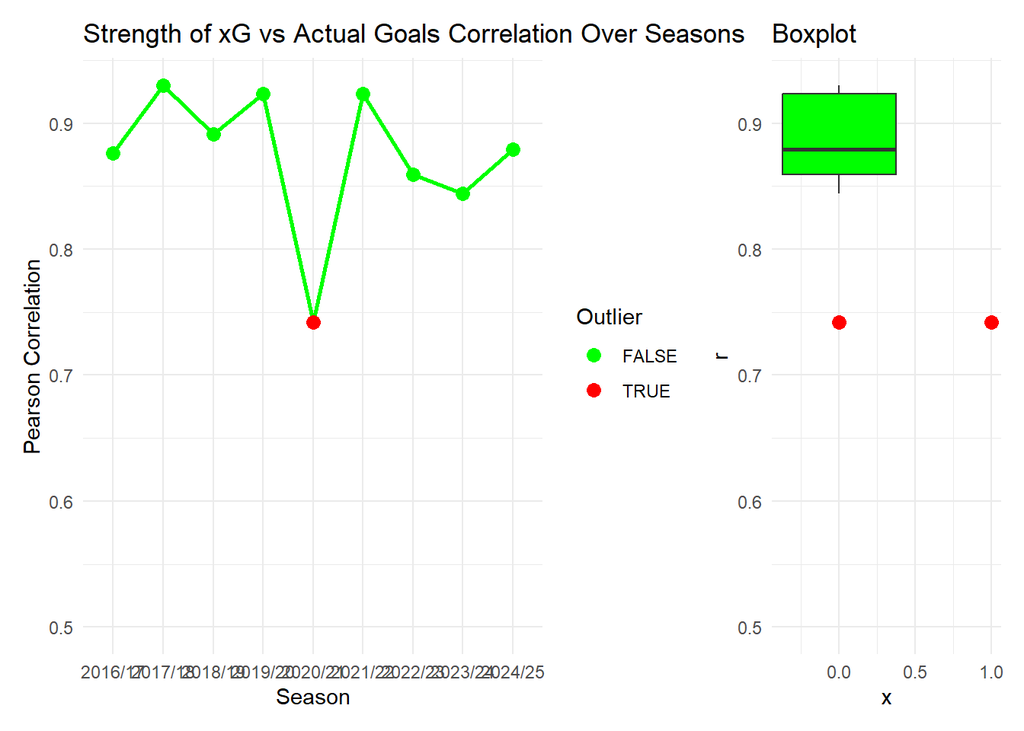

```r
# Combine plots side by side and display
line_plot + box_plot + plot_layout(ncol = 2, widths = c(2, 1))
```

#### Multiple Regression

Finally, I ran a multiple regression chart to further illustrate the consistency of xG since its introduction.

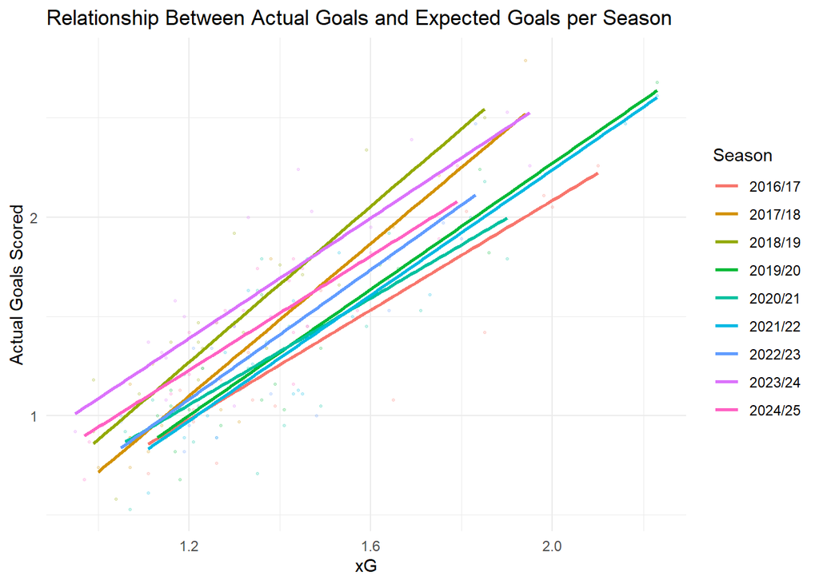

```r
# Multiple regression visualization by season
mr_plot<-ggplot(
  df,
  aes(
    x = Expected_goals,
    y = Actual_goals,
    colour = factor(Season)  ## Add separate regression lines for each season
    )
  ) +
  geom_point(alpha = 0.2, # Plot individual match observations and reduce size and transparacy
             size = 0.5) +
  geom_smooth(method = "lm", se = FALSE) + ## Add each line and remove CI
  labs( ## Add labs
    title = "Relationship Between Actual Goals and Expected Goals per Season",
    colour = "Season",
    x = "xG",
    y = "Actual Goals Scored"
  ) +
  theme_minimal() ## Keep theme
# Display plot
mr_plot
```

## Summary

### Key Findings

All the visualisations point to the same conclusion: expected goals (xG) is a strong predictor of actual goals scored. The overall correlation was high and stayed pretty consistent across seasons, which suggests xG is a reliable metric for understanding team performance. The only real exception was 2020/21, which stood out as an outlier—likely due to unusual circumstances that season (e.g., COVID disruptions).

In short, xG seems to do what it claims: give a good sense of how many goals a team should score based on chances created. This makes it useful for analysts and fans alike.

## Limitations

- I scraped the data myself, leading to potential transcription errors. Access to all the data would have been super beneficial
- My intention of longitudinal analysis here is limited since xG is still fairly novel. A larger sample would add power to both my research questions
- The 2020/21 season appeared as a slight outlier, potentially reflecting the unusual conditions of that season (COVID :/), perhaps exclude from analysis. I suppose it would have generally been harder to measure the variables used in xG throughout lock down etc.

### Future Work

If I had data available, in future work I would:

- Extend the analysis to other leagues
- Examine match-level rather than season-level data (player-level, even)
- Investigate how xG relates to points, wins, or league position.